Hi Azzurra and Frauke,

Frauke and I came up the other day with a possible modification to the instructions that might give children’s exploration on the box somewhat more meaning. **The bottom line:** *tell them it’s some combination that includes the red button*; this way, we get more hypothesis tests before success and perhaps greater probability that children keep exploring after success.

# So far

So far, the instructions either say nothing about specific combinations. Then the likelihood distribution logically looks like this (let’s call the four buttons A, B, C, D):

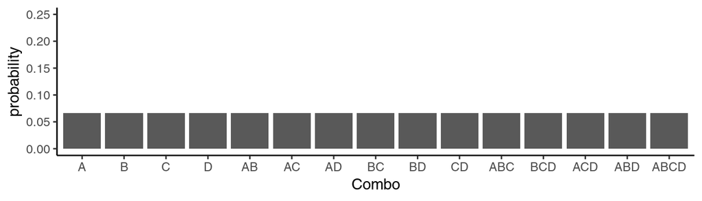

And children’s testing will likely be distributed like this:

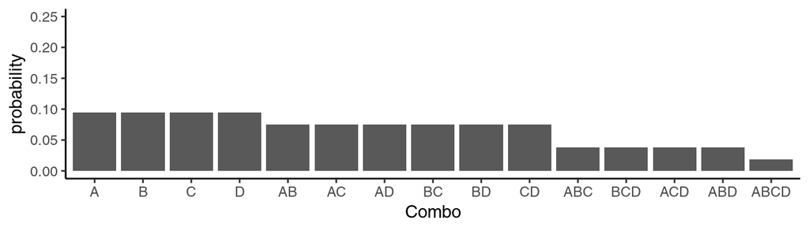

(Three-button combos are just harder to do motorically and they’re an idea you need to have in the first place, given you have 2 hands.)

When the instruction focused on one combination, children have often tested this one first. They are successful and from here it is not clear what motivates any further presses. So kids start out with a skewed likelihood distribution, something like this:

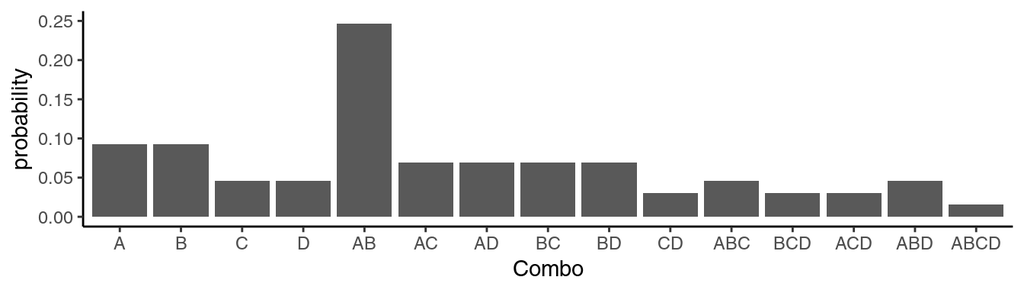

If AB is the combination, no matter what the exact wording in the instruction was, this combination is massively favored. And maybe A and B as single buttons, and *maybe* combinations that contain them are favored a little bit, too.

So the structuring of the hypothesis space is quite simple: It’s the mentioned combination vs. all the others.

# The idea

We can get a better structuring of the hypothesis space. We can give an instruction that goes like:

> (I think but might be wrong that…) The correct combination includes the A button.

This way, we partition the hypothesis space into the 8 combinations that contain the A button versus the others. From a logical standpoint, it looks like this:

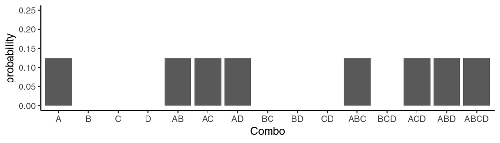

As kids will probably generally disfavor 3- and 4-button combinations and more happily explore simple (1/2 button) hypotheses, it might look like this:

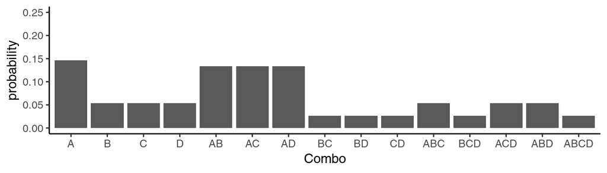

So what would be helpful about the proposed instruction is that children have an extra hypothesis sub-space that they can exhaust or not under different wordings. We can ask: Given the (sometimes epistemically qualified) weighting of the hypothesis space towards combinations containing A, did children exhaust the relevant sub-space before they turned to other combinations that do not contain A?

Perhaps we even get the box to cheat on children: To only light up when children press the third unique combination containing A. This way we give all children the same amount of time or tests before success, instead of ~1/3 of them hitting upon the successful combination at their first attempt.

What do you think?

## Script

*Roughly*, I can think of these instructions:

> Da ist der { graue, rote, schwarze, weiße } Schalter . Man kann die Lampe anmachen.

### C1: control

No influence on the hypothesis space:

> Man kann einen oder mehrere Knöpfe zusammen drücken.

### C2: unqualified

Direct, epistemically unqualified focus on the red button:

> Bei der richtigen Kombination ist der rote Knopf dabei.

### C3: qualified

Focus on red button, qualify epistemically:

> Ich dachte, bei der richtigen Kombination wäre der rote Knopf dabei?

### C4: –> Any other manipulations?

Note that I had some reservations with a previous condition in which E justs gives a looong list of 2-button combinations, maybe those were all six. For one, this de-emphasizes the possibility of 3-button combos. But more importantly, we wrestle here with memory as an extra factor, with recency and primacy effects, plus an instruction that seems a bit odd pragmatically.